# Demonstração ao vivo — Code chunks

Bloco 6 do minicurso

Autor

Julia Apolonio

Data de Publicação

18 de agosto de 2026

**DicaComo acompanhar**

Rode os chunks um a um. No fim, renderize o documento inteiro — várias coisas deste arquivo **só existem depois de renderizar**.

# 1 Preparação

Sempre o primeiro chunk. `include: false` faz ele executar sem aparecer.

# 2 O básico

Um chunk é código de verdade: roda, e o resultado entra no documento.

```r
x <- c(12, 15, 9, 22, 18)
mean(x)
```

```
[1] 15.2
```

# 3 Código inline

Em vez de digitar um número no texto, você o **calcula** no texto.

```r
notas <- c(7.5, 8.0, 6.2, 9.1, 5.8, 8.8, 7.0)
```

Agora escreva no meio de um parágrafo, entre crases, `r` e a expressão:

> Foram avaliadas 7 amostras, com média 7.49 e desvio-padrão 1.25. A maior nota foi 9.1.

# 4 Plots

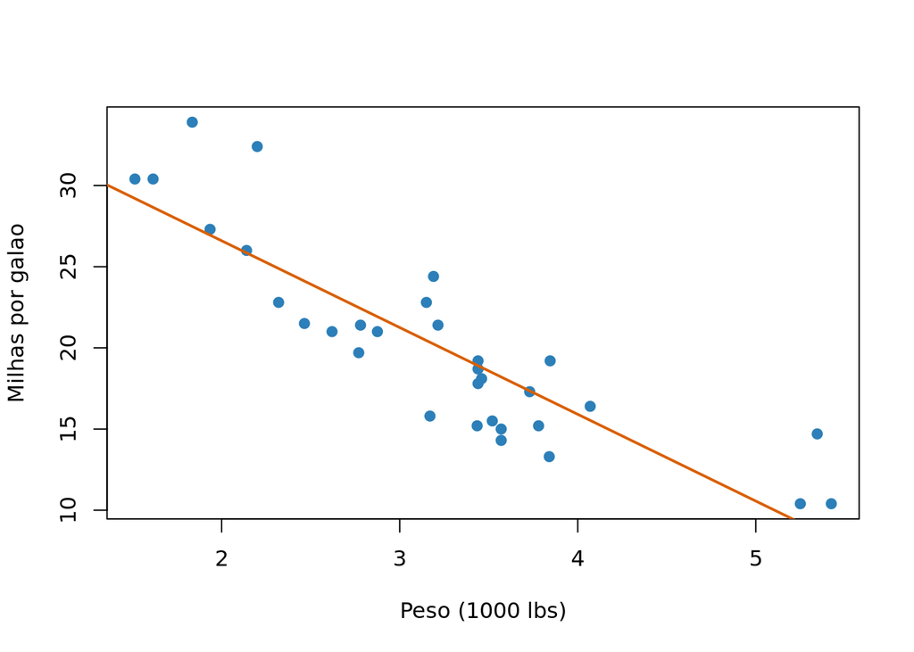

```r
plot(mtcars$wt, mtcars$mpg,
     pch = 19, col = "#2C7FB8",
     xlab = "Peso (1000 lbs)", ylab = "Milhas por galao")
abline(lm(mpg ~ wt, data = mtcars), col = "#D95F02", lwd = 2)
```

Agora com opções:

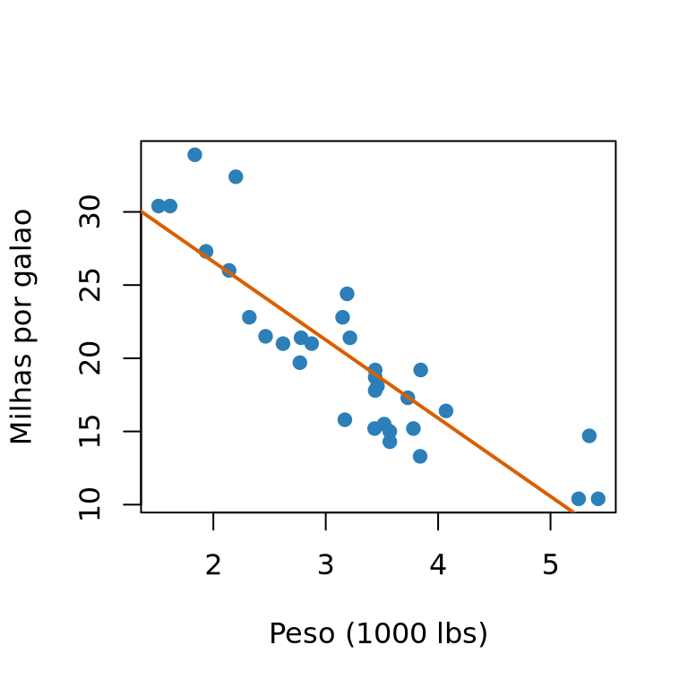

Figura 1: Relação entre peso e consumo no conjunto `mtcars`.

```r
##| column: margin

plot(mtcars$wt, mtcars$mpg,
     pch = 19, col = "#2C7FB8",
     xlab = "Peso (1000 lbs)", ylab = "Milhas por galao")
abline(lm(mpg ~ wt, data = mtcars), col = "#D95F02", lwd = 2)
```

## 4.1 Duas figuras num chunk só

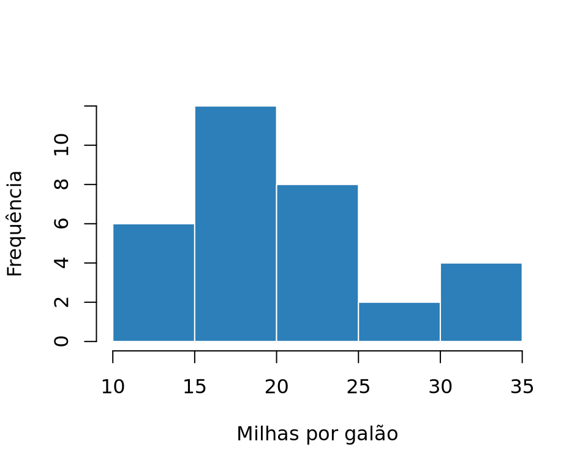

(a) Consumo

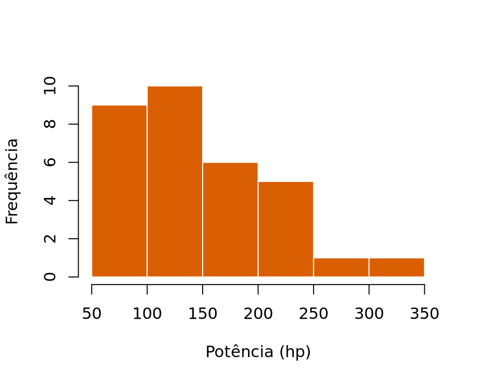

(b) Potência

Figura 2: Distribuições das variáveis do `mtcars`.

```r
hist(mtcars$mpg, col = "#2C7FB8", border = "white",
     main = "", xlab = "Milhas por galão", ylab = "Frequência")

hist(mtcars$hp, col = "#D95F02", border = "white",
     main = "", xlab = "Potência (hp)", ylab = "Frequência")
```

# 5 Tabelas

## 5.1 `kable` — o básico

```r
kable(head(mtcars[, c("mpg", "cyl", "hp", "wt")], 6),
      col.names = c("Consumo", "Cilindros", "Potência", "Peso"),
      digits = 2)
```

Tabela 1: Primeiras linhas do `mtcars`.

|  | Consumo | Cilindros | Potência | Peso |
| --- | --- | --- | --- | --- |
| Mazda RX4 | 21.0 | 6 | 110 | 2.62 |
| Mazda RX4 Wag | 21.0 | 6 | 110 | 2.88 |
| Datsun 710 | 22.8 | 4 | 93 | 2.32 |
| Hornet 4 Drive | 21.4 | 6 | 110 | 3.21 |
| Hornet Sportabout | 18.7 | 8 | 175 | 3.44 |
| Valiant | 18.1 | 6 | 105 | 3.46 |

## 5.2 `gt` — tabela de publicação

```r
library(gt)

head(mtcars[, c("mpg", "cyl", "hp")], 4) |>
  gt(rownames_to_stub = TRUE) |>
  tab_header(title = "Consumo por modelo") |>
  fmt_number(columns = mpg, decimals = 1) |>
  tab_source_note("Fonte: Motor Trend, 1974.")
```

Consumo por modelo

|  | mpg | cyl | hp |
| --- | --- | --- | --- |
| Mazda RX4 | 21.0 | 6 | 110 |
| Mazda RX4 Wag | 21.0 | 6 | 110 |
| Datsun 710 | 22.8 | 4 | 93 |
| Hornet 4 Drive | 21.4 | 6 | 110 |

Fonte: Motor Trend, 1974.

## 5.3 `kableExtra` — agrupamentos e cores

```r
library(kableExtra)
kbl(head(mtcars[, 1:3], 4)) |>
  kable_styling(bootstrap_options = c("striped", "hover"),
                full_width = FALSE) |>
  add_header_above(c(" " = 1, "Motor" = 3)) |>
  column_spec(2, color = "white", background = "#2C7FB8")
```

|  | Motor mpg | Motor cyl | Motor disp |
| --- | --- | --- | --- |
| Mazda RX4 | 21.0 | 6 | 160 |
| Mazda RX4 Wag | 21.0 | 6 | 160 |
| Datsun 710 | 22.8 | 4 | 108 |
| Hornet 4 Drive | 21.4 | 6 | 258 |

## 5.4 `DT` — interativa, só em HTML

```r
DT::datatable(mtcars[, 1:5],
              options = list(pageLength = 5))
```

|  | mpg | cyl | disp | hp | drat |
| --- | --- | --- | --- | --- | --- |
| Mazda RX4 | 21 | 6 | 160 | 110 | 3.9 |
| Mazda RX4 Wag | 21 | 6 | 160 | 110 | 3.9 |
| Datsun 710 | 22.8 | 4 | 108 | 93 | 3.85 |
| Hornet 4 Drive | 21.4 | 6 | 258 | 110 | 3.08 |
| Hornet Sportabout | 18.7 | 8 | 360 | 175 | 3.15 |
| Valiant | 18.1 | 6 | 225 | 105 | 2.76 |
| Duster 360 | 14.3 | 8 | 360 | 245 | 3.21 |
| Merc 240D | 24.4 | 4 | 146.7 | 62 | 3.69 |
| Merc 230 | 22.8 | 4 | 140.8 | 95 | 3.92 |
| Merc 280 | 19.2 | 6 | 167.6 | 123 | 3.92 |

[output cut: 22 more lines]

# 6 Cross-references

## 6.1 Figuras

A Figura 1 mostra a tendência decrescente, e a Figura 2 traz as distribuições. Os números da Tabela 1 vêm do mesmo conjunto.

## 6.2 Tabelas

Tabela de pipe, com legenda usando `:` e `id` começando em `tbl-`:

Tabela 2: Motores de execução por linguagem

| Linguagem | Motor |
| --- | --- |
| R | `knitr` |
| Python | `jupyter` |

A Tabela 2 mostra os dois motores mais comuns.

Tabela, via chunk:

```r
knitr::kable(head(mtcars[, 1:3], 3))
```

Tabela 3: Primeiras linhas do mtcars.

|  | mpg | cyl | disp |
| --- | --- | --- | --- |
| Mazda RX4 | 21.0 | 6 | 160 |
| Mazda RX4 Wag | 21.0 | 6 | 160 |
| Datsun 710 | 22.8 | 4 | 108 |

Já a Tabela 3 foi gerada por código.

## 6.3 Equação

Bloco de LaTeX com `id` começando em `eq-`:

$$IMC = \frac{peso}{altura^2}
\tag{1}$$

A Equação 1 é a fórmula clássica do índice de massa corporal.

## 6.4 Seção

Um título com `id` começando em `sec-` (exige `number-sections: true` no YAML):

### 6.4.1 Métodos

Texto qualquer da seção.

Conforme descrito na Seção 6.4.1, o procedimento foi…

**AvisoIsto só funciona depois de renderizar**

No console, `@fig-dispersao` é texto puro. A numeração e o link são criados na renderização — e se você inserir uma figura antes, tudo se renumera sozinho.

# 7 Outras linguagens

```bash
ls
echo Hello World
```

```python
print("Hello World")

import os
print(os.listdir())
```

O motor `knitr` também executa Python — via `reticulate` — mas cada linguagem tem seu próprio ambiente por trás. Para fazer um documento 100% em python, é melhor usar o motor `jupyter`